# Prediction Assignment

Ramon Schildknecht

6/28/2017

# Summary

The goal of this assignment is to predict one of five exercice classes respectively executions types according to test attendants movements. The exercice is called [Unilateral Dumbbell Biceps Curl](https://www.youtube.com/watch?v=nD5kstcESZ0). The links leads to a video that shows you the ideal movement.

We took the 3 most common model methods to solve the problem. The method with the best accuracy was Random Forest with a accuracy of 99.8%.

The model predicted 20 classes out of 20 from the given test dataset.

# Overview

You will find the complete task description [here](https://www.evernote.com/l/Ai-5Q3ehW1BHjJOkY2Zus1q2KzCKfpWrkqQ). You can find the used data there.

The goal is mentioned in the summary above.

# Data description

Six young health participants were asked to perform one set of 10 repetitions of the Unilateral Dumbbell Biceps Curl in five different fashions: exactly according to the specification (Class A), throwing the elbows to the front (Class B), lifting the dumbbell only halfway (Class C), lowering the dumbbell only halfway (Class D) and throwing the hips to the front (Class E).

You will find data details [here](http://groupware.les.inf.puc-rio.br/har) in the section “Weight Lifting Exercises Dataset”.

I thank Ugulino, W.; Cardador, D.; Vega, K.; Velloso, E.; Milidiu, R.; Fuks, H. a lot for providing the valueable data. Their publication can be found [here](http://groupware.les.inf.puc-rio.br/work.jsf?p1=10335).

# Preparation

## Loading packages & set seed

## Load necessary data

```r
d.training <- data.frame(read_csv("http://d396qusza40orc.cloudfront.net/predmachlearn/pml-training.csv"))
d.test <- data.frame(read_csv("http://d396qusza40orc.cloudfront.net/predmachlearn/pml-testing.csv"))
```

## Split training set

```r
split.training <- createDataPartition(d.training$classe, p=0.7, list=FALSE)
training.set <- d.training[split.training, ]
testing.set  <- d.training[-split.training, ]
training.set$classe <- na.omit(training.set$classe)
dim.training <- dim(training.set)
dim.test <- dim(testing.set)
(dim.all <- data.table(dim.training, dim.test)) #first line = rowcounts, second line = columncounts
```

```
##    dim.training dim.test
## 1:        13737     5885
## 2:          160      160
```

There are 160 variables in both data subsets.

## Data Cleaning

There are a lot of [Near-zero variance (nzv) variables](https://tgmstat.wordpress.com/2014/03/06/near-zero-variance-predictors/). Therefore we remove them.

```r
nzv <- nearZeroVar(training.set)
training.set <- training.set[, -nzv]
testing.set <- testing.set[, -nzv]
dim.training <- dim(training.set)
dim.test <- dim(testing.set)
(dim.all <- data.table(dim.training, dim.test))
```

```
##    dim.training dim.test
## 1:        13737     5885
## 2:          128      128
```

Check for missing values

```r
mean(is.na(training.set))
```

```
## [1] 0.5284974
```

```r
mean(is.na(testing.set))
```

```
## [1] 0.5267736
```

There are a lot of overall missing values (> 50%) in the data sets.

We remove variables with count of missing values greater than 90% and remove remaining NA values.

```r
all.nas    <- sapply(training.set, function(x) mean(is.na(x))) > 0.90
training.set <- training.set[, all.nas==FALSE]
testing.set  <- testing.set[, all.nas==FALSE]
training.set <- na.omit(training.set)
dim.training <- dim(training.set)
dim.test <- dim(testing.set)
(dim.all <- data.table(dim.training, dim.test))
```

```
##    dim.training dim.test
## 1:        13736     5885
## 2:           59       59
```

In a last step we remove the first five ID variables that are not relevant as feature.

```r
training.set <- training.set[, -(1:5)]
testing.set <- testing.set[, -(1:5)]
dim.training <- dim(training.set)
dim.test <- dim(testing.set)
(dim.all <- data.table(dim.training, dim.test))
```

```
##    dim.training dim.test
## 1:        13736     5885
## 2:           54       54
```

We reduced our count of variables from 160 to 54 in the cleaning process.

# Exploratory Data Analysis

## Correlations

We check for correlations and ignore target Variable.

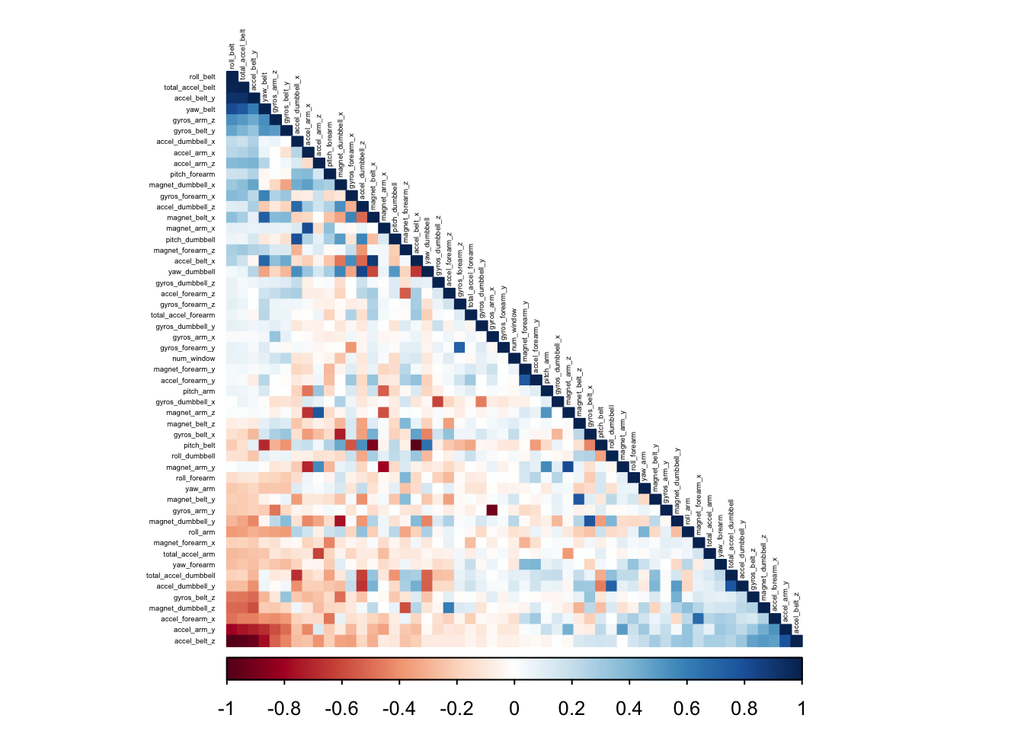

```r
correlation.matrix <- cor(training.set[, -54])
corrplot(correlation.matrix, order = "FPC",             method = "color", type = "lower",              tl.cex = 0.3, tl.col = rgb(0, 0, 0))
```

# Machine Learning Models

We will build three models with different methods from our cleaned training data set. Afterwards we use the one method performing the highest accuracy in the test dataset.

The three methods are: 1. Generalized Boosted Model 2. Decision Three 3. Random Forests

## Method Generalized Boosted Model

```r
#fit model
set.seed(55555)
control.gbm <- trainControl(method = "repeatedcv", number = 5, repeats = 1)
mod.fit.gbm  <- train(classe ~ ., data = training.set, method = "gbm", verbose = FALSE, trControl = control.gbm)
mod.fit.gbm$finalModel
```

```
## A gradient boosted model with multinomial loss function.
## 150 iterations were performed.
## There were 53 predictors of which 43 had non-zero influence.
```

```r
#prediction on test data
predict.gbm <- predict(mod.fit.gbm, newdata = testing.set)
confusion.matrix.gbm <- confusionMatrix(predict.gbm, testing.set$classe)
confusion.matrix.gbm
```

```
## Confusion Matrix and Statistics
##
##           Reference
## Prediction    A    B    C    D    E
##          A 1672   15    0    1    2
##          B    2 1113   11    3    2
##          C    0   11 1008    9    2
##          D    0    0    6  949   13
##          E    0    0    1    2 1063
##
## Overall Statistics
##
##                Accuracy : 0.9864
##                  95% CI : (0.9831, 0.9892)
##     No Information Rate : 0.2845
##     P-Value [Acc > NIR] : < 2.2e-16
##
##                   Kappa : 0.9828
##  Mcnemar's Test P-Value : NA
##
## Statistics by Class:
##
##                      Class: A Class: B Class: C Class: D Class: E
## Sensitivity            0.9988   0.9772   0.9825   0.9844   0.9824
## Specificity            0.9957   0.9962   0.9955   0.9961   0.9994
## Pos Pred Value         0.9893   0.9841   0.9786   0.9804   0.9972
## Neg Pred Value         0.9995   0.9945   0.9963   0.9969   0.9961
## Prevalence             0.2845   0.1935   0.1743   0.1638   0.1839
## Detection Rate         0.2841   0.1891   0.1713   0.1613   0.1806
## Detection Prevalence   0.2872   0.1922   0.1750   0.1645   0.1811
## Balanced Accuracy      0.9973   0.9867   0.9890   0.9903   0.9909
```

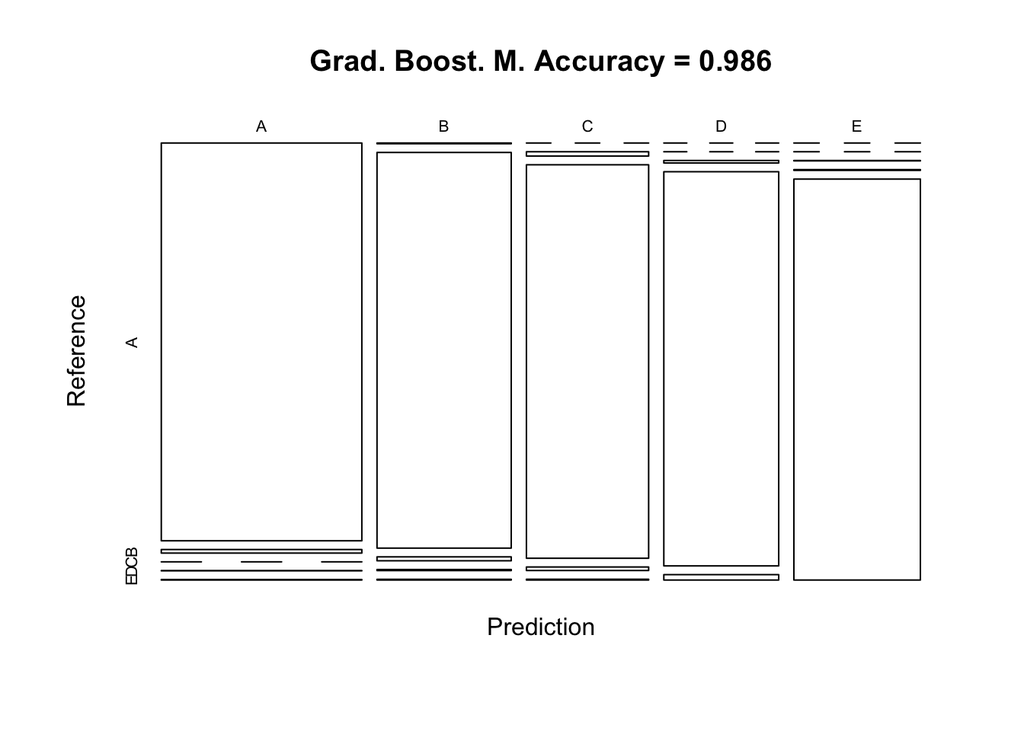

```r
#show results
plot(confusion.matrix.gbm$table, col = confusion.matrix.gbm$byClass,
     main = paste("Grad. Boost. M. Accuracy =", round(confusion.matrix.gbm$overall['Accuracy'], 3)))
```

## Method Decision Three

[figure not shown]

```r
#fit model
set.seed(55555)
mod.fit.dt <- rpart(classe ~ ., data=training.set, method="class")
plot(mod.fit.dt, uniform = TRUE, main = "Decision Three")
text(mod.fit.dt, use.n = TRUE, all = TRUE, cex = .7)
```

```r
#prediction on test data
predict.dt <- predict(mod.fit.dt, newdata=testing.set, type="class")
confusion.matrix.dt <- confusionMatrix(predict.dt, testing.set$classe)
confusion.matrix.dt
```

```
## Confusion Matrix and Statistics
##
##           Reference
## Prediction    A    B    C    D    E
##          A 1497  185   41   59   57
##          B  109  757   99  134  157
##          C   16   68  766  151   91
##          D   26   70   53  563   84
##          E   26   59   67   57  693
##
## Overall Statistics
##
##                Accuracy : 0.7266
##                  95% CI : (0.715, 0.738)
##     No Information Rate : 0.2845
##     P-Value [Acc > NIR] : < 2.2e-16
##
##                   Kappa : 0.6526
##  Mcnemar's Test P-Value : < 2.2e-16
##
## Statistics by Class:
##
##                      Class: A Class: B Class: C Class: D Class: E
## Sensitivity            0.8943   0.6646   0.7466  0.58402   0.6405
## Specificity            0.9188   0.8949   0.9329  0.95265   0.9565
## Pos Pred Value         0.8140   0.6027   0.7015  0.70729   0.7683
## Neg Pred Value         0.9563   0.9175   0.9458  0.92120   0.9219
## Prevalence             0.2845   0.1935   0.1743  0.16381   0.1839
## Detection Rate         0.2544   0.1286   0.1302  0.09567   0.1178
## Detection Prevalence   0.3125   0.2134   0.1856  0.13526   0.1533
## Balanced Accuracy      0.9065   0.7797   0.8397  0.76834   0.7985
```

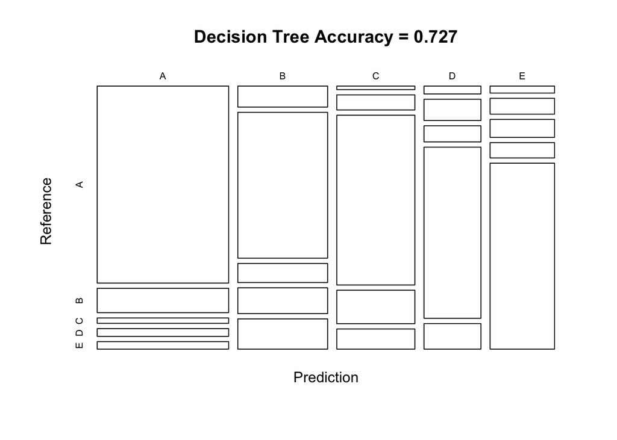

```r
#show results
plot(confusion.matrix.dt$table, col = confusion.matrix.dt$byClass,
     main = paste("Decision Tree Accuracy =",
                  round(confusion.matrix.dt$overall['Accuracy'],3)))
```

## Method Random Forests

```r
#fit model
set.seed(55555)
control.rf <- trainControl(method="cv", number=3, verboseIter = FALSE)
model.fit.rf <- train(classe ~ ., data = training.set, method="rf", trControl = control.rf)
model.fit.rf$finalModel
```

```
##
## Call:
##  randomForest(x = x, y = y, mtry = param$mtry)
##                Type of random forest: classification
##                      Number of trees: 500
## No. of variables tried at each split: 27
##
##         OOB estimate of  error rate: 0.25%
## Confusion matrix:
##      A    B    C    D    E class.error
## A 3905    0    0    0    0 0.000000000
## B    7 2646    3    2    0 0.004514673
## C    0    5 2391    0    0 0.002086811
## D    0    0    8 2243    1 0.003996448
## E    0    1    0    7 2517 0.003168317
```

```r
#prediction on test data
predict.rf <- predict(model.fit.rf, newdata = testing.set)
confusion.matrix.rf <- confusionMatrix(predict.rf, testing.set$classe)
confusion.matrix.rf
```

```
## Confusion Matrix and Statistics
##
##           Reference
## Prediction    A    B    C    D    E
##          A 1674    2    0    0    0
##          B    0 1137    4    0    0
##          C    0    0 1022    1    0
##          D    0    0    0  963    2
##          E    0    0    0    0 1080
##
## Overall Statistics
##
##                Accuracy : 0.9985
##                  95% CI : (0.9971, 0.9993)
##     No Information Rate : 0.2845
##     P-Value [Acc > NIR] : < 2.2e-16
##
##                   Kappa : 0.9981
##  Mcnemar's Test P-Value : NA
##
## Statistics by Class:
##
##                      Class: A Class: B Class: C Class: D Class: E
## Sensitivity            1.0000   0.9982   0.9961   0.9990   0.9982
## Specificity            0.9995   0.9992   0.9998   0.9996   1.0000
## Pos Pred Value         0.9988   0.9965   0.9990   0.9979   1.0000
## Neg Pred Value         1.0000   0.9996   0.9992   0.9998   0.9996
## Prevalence             0.2845   0.1935   0.1743   0.1638   0.1839
## Detection Rate         0.2845   0.1932   0.1737   0.1636   0.1835
## Detection Prevalence   0.2848   0.1939   0.1738   0.1640   0.1835
## Balanced Accuracy      0.9998   0.9987   0.9979   0.9993   0.9991
```

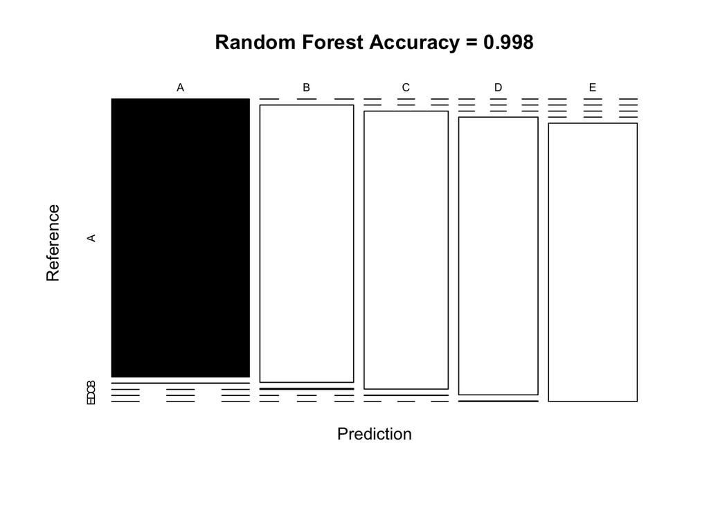

```r
#show results
plot(confusion.matrix.rf$table, col = confusion.matrix.rf$byClass,
     main = paste("Random Forest Accuracy =",
     round(confusion.matrix.rf$overall['Accuracy'], 3)))
```

# Compare model methods results on test data and decide for the best method

We saw above the following 3 model accuracies:

1. Generalized Boosted Model: 0.986 rank 2
2. Decision Three: 0.727 rank 3
3. Random Forests: 0.998 rank 1

**The best method is Random Forests** and we apply it to answer the 20 quiz questions. We will see the results at the end of this document.

```r
predict.quiz <- predict(model.fit.rf, newdata  = d.test)
intervall.1.to.20 <- 1:20
data.table(intervall.1.to.20, predict.quiz)
```

```
##     intervall.1.to.20 predict.quiz
##  1:                 1            B
##  2:                 2            A
##  3:                 3            B
##  4:                 4            A
##  5:                 5            A
##  6:                 6            E
##  7:                 7            D
##  8:                 8            B
##  9:                 9            A
## 10:                10            A
## 11:                11            B
## 12:                12            C
## 13:                13            B
## 14:                14            A
## 15:                15            E
## 16:                16            E
## 17:                17            A
## 18:                18            B
## 19:                19            B
## 20:                20            B
```